# Group A — Explore & Plot: Deep Dive into the Numbers

Author

Workshop Participant

In this session we go deep on the raw numbers — distributions, skew, suspicious values — then build plots and **re-make one plot three times** to learn what each tweak reveals.

```r
library(tidyverse)
library(moments)

sample_ids   <- read_csv("../../data/group_a_yogurt/00_sample_ids_yogurt.csv", show_col_types = FALSE)
participants <- read_csv("../../data/group_a_yogurt/01_participant_metadata_yogurt.csv", show_col_types = FALSE)
qpcr         <- read_csv("../../data/group_a_yogurt/02_qpcr_results_yogurt.csv", show_col_types = FALSE)
luminex      <- read_csv("../../data/group_a_yogurt/03_luminex_results_yogurt.csv", show_col_types = FALSE)

qjoined <- sample_ids |> left_join(qpcr, by = "sample_id")
ljoined <- sample_ids |> left_join(luminex, by = "sample_id")
```

## 1. Distributions — participant metadata

### Age

Age is roughly symmetric, centred around 31, range 24–37.

```r
summary(participants$age)
```

```
   Min. 1st Qu.  Median    Mean 3rd Qu.    Max.
  24.00   28.00   31.00   30.73   33.00   37.00
```

```r
cat("SD:", sd(participants$age), "| Skewness:", skewness(participants$age))
```

```
SD: 3.286813 | Skewness: -0.04784677
```

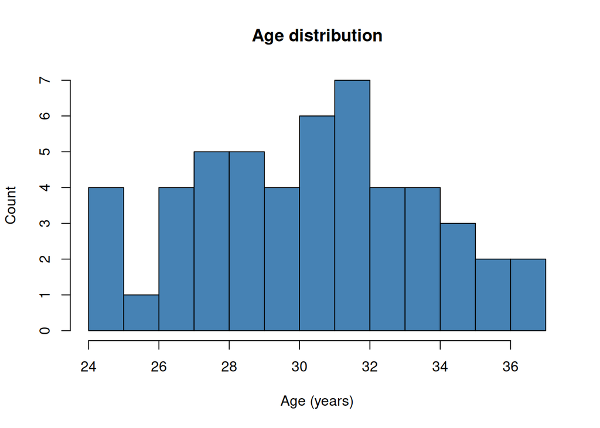

```r
hist(participants$age, breaks = 10, col = "steelblue",
     main = "Age distribution", xlab = "Age (years)", ylab = "Count")
```

### Days since last sex

This one is **right-skewed** (skewness = 2.46). Most values are 1–10 days, but a few go up to 48. Worth asking: are these extreme values real, or data entry errors?

```r
summary(participants$days_since_last_sex)
```

```
   Min. 1st Qu.  Median    Mean 3rd Qu.    Max.
   1.00    3.00    5.00    8.49   10.50   48.00
```

```r
cat("SD:", sd(participants$days_since_last_sex), "| IQR:", IQR(participants$days_since_last_sex))
```

```
SD: 9.390149 | IQR: 7.5
```

```r
cat("Values > 14 days:", sum(participants$days_since_last_sex > 14))
```

```
Values > 14 days: 6
```

```r
cat(" | > 30 days:", sum(participants$days_since_last_sex > 30))
```

```
 | > 30 days: 2
```

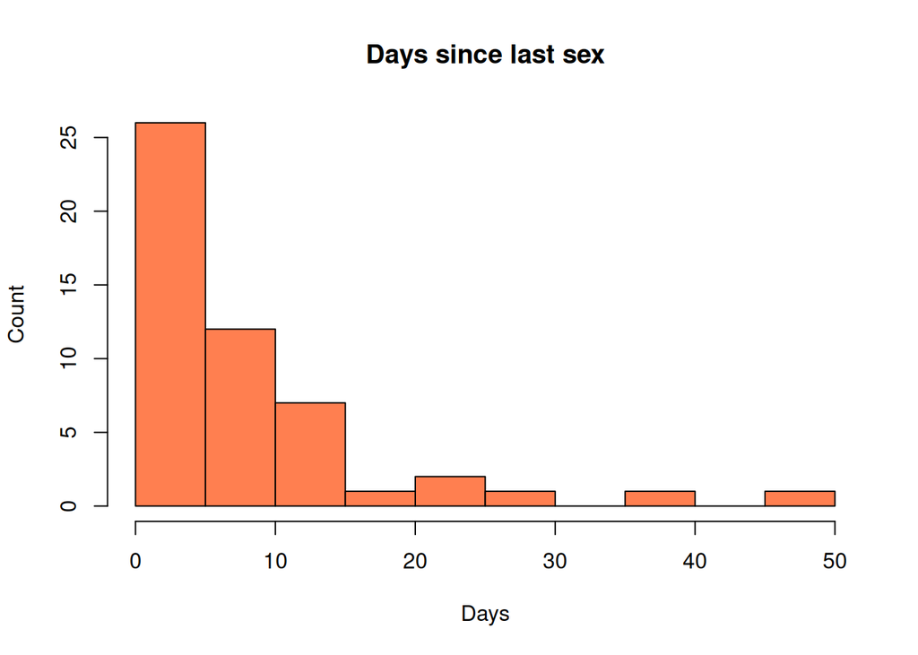

```r
hist(participants$days_since_last_sex, breaks = 15, col = "coral",
     main = "Days since last sex", xlab = "Days", ylab = "Count")
```

## 2. Distributions — qPCR (bacterial DNA)

All three qPCR variables are **heavily right-skewed** — a few samples have very high values while most are low.

### Total bacterial load

```r
summary(qpcr$qpcr_bacteria)
```

```
     Min.   1st Qu.    Median      Mean   3rd Qu.      Max.
     4252    264994   2236996   9351185   7532202 126400280
```

```r
cat("SD:", sd(qpcr$qpcr_bacteria), "| Skewness:", round(skewness(qpcr$qpcr_bacteria), 2))
```

```
SD: 19359669 | Skewness: 3.55
```

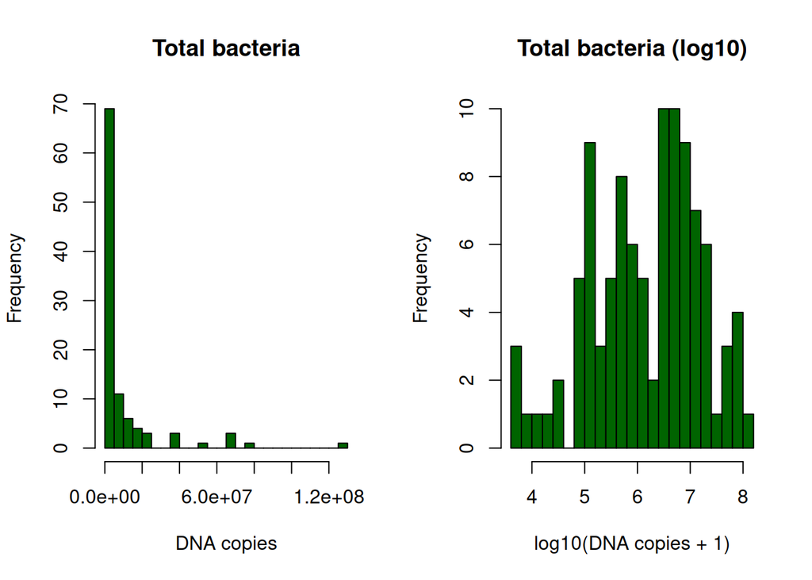

```r
par(mfrow = c(1, 2))
hist(qpcr$qpcr_bacteria, breaks = 30, col = "darkgreen",
     main = "Total bacteria", xlab = "DNA copies")
hist(log10(qpcr$qpcr_bacteria + 1), breaks = 30, col = "darkgreen",
     main = "Total bacteria (log10)", xlab = "log10(DNA copies + 1)")
```

The log10 transform reveals a bimodal distribution — two peaks. That’s interesting and worth looking into by group.

### *L. crispatus*

```r
summary(qpcr$qpcr_crispatus)
```

```
     Min.   1st Qu.    Median      Mean   3rd Qu.      Max.
      0.0       0.0       0.0   95443.0      48.2 6572278.4
```

```r
cat("Skewness:", round(skewness(qpcr$qpcr_crispatus), 2))
```

```
Skewness: 9.41
```

```r
cat("Zeros:", sum(qpcr$qpcr_crispatus == 0), "/", nrow(qpcr),
    "=", round(mean(qpcr$qpcr_crispatus == 0) * 100, 1), "%")
```

```
Zeros: 66 / 102 = 64.7 %
```

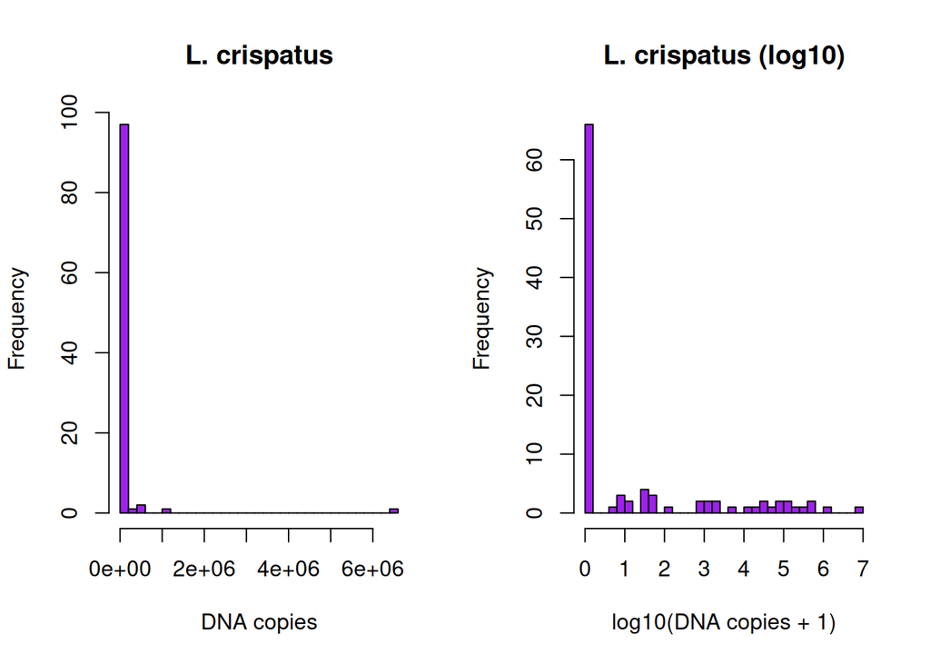

```r
par(mfrow = c(1, 2))
hist(qpcr$qpcr_crispatus, breaks = 30, col = "purple",
     main = "L. crispatus", xlab = "DNA copies")
hist(log10(qpcr$qpcr_crispatus + 1), breaks = 30, col = "purple",
     main = "L. crispatus (log10)", xlab = "log10(DNA copies + 1)")
```

64.7% of samples have zero *L. crispatus*. The log-scale plot shows data clusters at zero (left bar) and then a long tail of non-zero values.

### *L. iners*

```r
summary(qpcr$qpcr_iners)
```

```
     Min.   1st Qu.    Median      Mean   3rd Qu.      Max.
      0.0      22.3   32352.7  291916.1  302450.4 3854096.8
```

```r
cat("SD:", sd(qpcr$qpcr_iners), "| Skewness:", round(skewness(qpcr$qpcr_iners), 2))
```

```
SD: 653410.4 | Skewness: 3.8
```

```r
cat("Zeros:", sum(qpcr$qpcr_iners == 0), "/", nrow(qpcr))
```

```
Zeros: 8 / 102
```

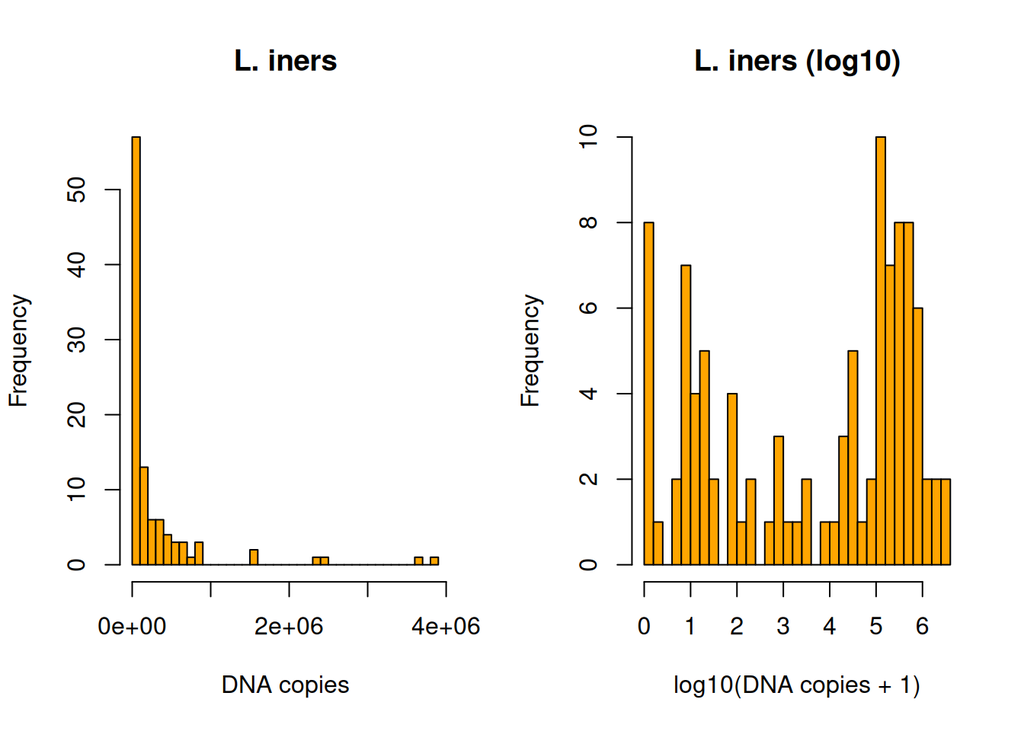

```r
par(mfrow = c(1, 2))
hist(qpcr$qpcr_iners, breaks = 30, col = "orange",
     main = "L. iners", xlab = "DNA copies")
hist(log10(qpcr$qpcr_iners + 1), breaks = 30, col = "orange",
     main = "L. iners (log10)", xlab = "log10(DNA copies + 1)")
```

Only 8 out of 102 samples have zero *L. iners* — almost everyone has some. The distribution is still heavily skewed.

## 3. Suspicious values

### Extreme outliers in qPCR

Using the “3 × IQR beyond Q3” rule:

```r
check <- function(x, nm) {
  q3 <- quantile(x, 0.75); q1 <- quantile(x, 0.25)
  thr <- q3 + 3 * (q3 - q1)
  extreme <- x[x > thr]
  cat(nm, "- threshold:", round(thr, 1), "| count:", length(extreme), "\n")
  if (length(extreme) > 0) {
    print(sort(extreme, decreasing = TRUE))
  }
}
check(qpcr$qpcr_bacteria, "Total bacteria")
```

```
Total bacteria - threshold: 29333827 | count: 9
[1] 126400280  78581750  65059240  65059240  65059240  54468164  39892616
[8]  39833824  35260360
```

```r
check(qpcr$qpcr_crispatus, "L. crispatus")
```

```
L. crispatus - threshold: 192.6 | count: 22
 [1] 6572278.400 1040093.880  539327.800  518340.340  308138.540  187931.720
 [7]  147887.680  116559.940   73925.132   65541.492   57770.704   30850.400
[13]   30850.400   21060.826   11636.088    4586.006    2011.896    2011.896
[19]    1119.092    1119.092     812.958     812.958
```

```r
check(qpcr$qpcr_iners, "L. iners")
```

```
L. iners - threshold: 1209735 | count: 6
[1] 3854097 3670552 2479934 2350547 1555847 1555847
```

Total bacteria has 9 extreme values — are these from one group or time point? Let’s check:

```r
qjoined |>
  filter(qpcr_bacteria > quantile(qpcr$qpcr_bacteria, 0.75) +
         3 * IQR(qpcr$qpcr_bacteria)) |>
  select(sample_id, arm, time_point, qpcr_bacteria)
```

```
# A tibble: 9 × 4
  sample_id arm            time_point qpcr_bacteria
  <chr>     <chr>          <chr>              <dbl>
1 UNCH048   unchanged_diet baseline        39892616
2 YOG069    yogurt         baseline        78581750
3 UNCH072   unchanged_diet baseline        54468164
4 UNCH077   unchanged_diet baseline        39833824
5 YOG078    yogurt         baseline       126400280
6 YOG080    yogurt         baseline        65059240
7 YOG086    yogurt         baseline        35260360
8 UNCH100   unchanged_diet baseline        65059240
9 UNCH101   unchanged_diet baseline        65059240
```

### Luminex: out-of-range measurements

```r
# Which cytokines are most affected?
luminex |>
  count(cytokine, limits) |>
  group_by(cytokine) |>
  mutate(pct = round(n / sum(n) * 100, 1)) |>
  filter(limits == "out of range") |>
  arrange(desc(pct))
```

```
# A tibble: 9 × 4
# Groups:   cytokine [9]
  cytokine limits           n   pct
  <chr>    <chr>        <int> <dbl>
1 IL-10    out of range   102 100
2 IFN-Y    out of range   101  99
3 TNFa     out of range   100  98
4 IL-6     out of range    77  75.5
5 IL-1b    out of range    74  72.5
6 MIP-3a   out of range    24  23.5
7 MIG      out of range    13  12.7
8 IL-8     out of range     4   3.9
9 IP-10    out of range     3   2.9
```

**Key finding:** IL-10 (100%), IFN-Y (99%), and TNFa (98%) are virtually unmeasurable — almost all values are “out of range”. These cytokines might be below the detection limit of the assay in vaginal samples.

Most out-of-range measurements are at a **single value** (below detection), but a few (MIG, IP-10, IL-8) have some very high values that are literally “off the charts” (>25,000 pg/mL).

## 4. Missing data

```r
cat("No missing values in any table.\n")
```

```
No missing values in any table.
```

```r
cat("sample_ids:  ", sum(complete.cases(sample_ids)), "/", nrow(sample_ids), "\n")
```

```
sample_ids:   102 / 102
```

```r
cat("participants:", sum(complete.cases(participants)), "/", nrow(participants), "\n")
```

```
participants: 51 / 51
```

```r
cat("qpcr:        ", sum(complete.cases(qpcr)), "/", nrow(qpcr), "\n")
```

```
qpcr:         102 / 102
```

```r
cat("luminex:     ", sum(complete.cases(luminex)), "/", nrow(luminex), "\n")
```

```
luminex:      1020 / 1020
```

There are **zero missing values** anywhere. The README hinted that `days_since_last_sex` might have NAs, but it doesn’t. The data is clean.

## 5. Making a plot — and remaking it three times

Let’s zoom in on one question: **Does total bacterial load differ between the yogurt and unchanged diet groups after antibiotics?**

I’ll make this plot, get feedback, then improve it. The goal is not to create three different plots, but to **make the same plot three times**, each time learning something.

### Attempt 1 — Raw plot, first draft

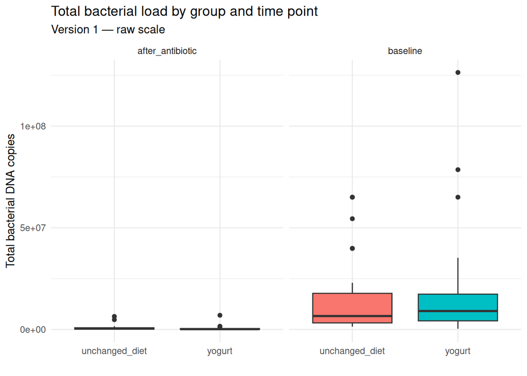

```r
p1 <- qjoined |>
  ggplot(aes(x = arm, y = qpcr_bacteria, fill = arm)) +
  geom_boxplot() +
  facet_wrap(~ time_point) +
  labs(title = "Total bacterial load by group and time point",
       subtitle = "Version 1 — raw scale",
       y = "Total bacterial DNA copies", x = "") +
  theme_minimal() +
  theme(legend.position = "none")
p1
```

**What I see:** The y-axis is dominated by a few extreme values. You can’t see what’s happening in the lower range at all. Most samples are squished at the bottom.

### Attempt 2 — Log scale

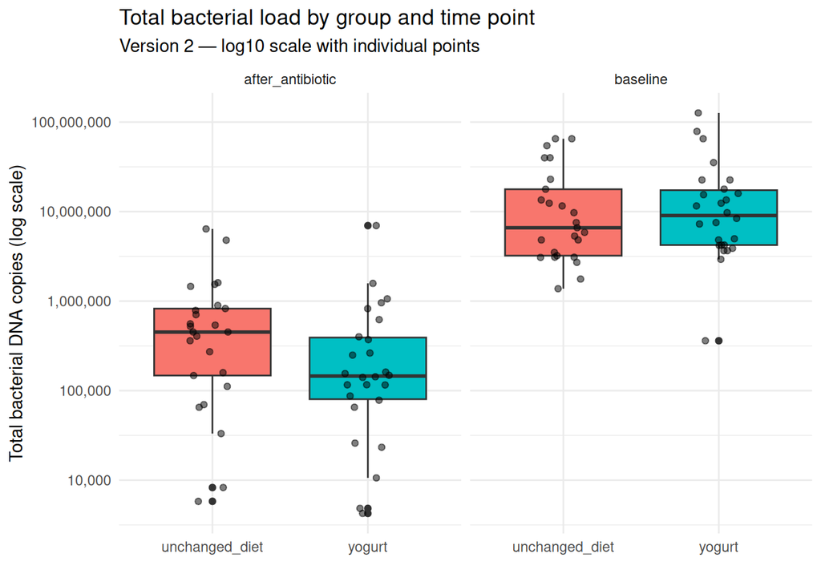

```r
p2 <- qjoined |>
  ggplot(aes(x = arm, y = qpcr_bacteria, fill = arm)) +
  geom_boxplot() +
  geom_jitter(width = 0.15, alpha = 0.5, size = 1.5) +
  facet_wrap(~ time_point) +
  scale_y_log10(labels = scales::comma) +
  labs(title = "Total bacterial load by group and time point",
       subtitle = "Version 2 — log10 scale with individual points",
       y = "Total bacterial DNA copies (log scale)", x = "") +
  theme_minimal() +
  theme(legend.position = "none")
p2
```

**What I see:** The log scale reveals structure that was invisible before. At baseline the groups look similar. After antibiotics, the yogurt group looks like it might have *lower* total bacteria overall — is that real? The jitter shows individual samples so we can see the spread.

### Attempt 3 — Paired lines showing change within each person

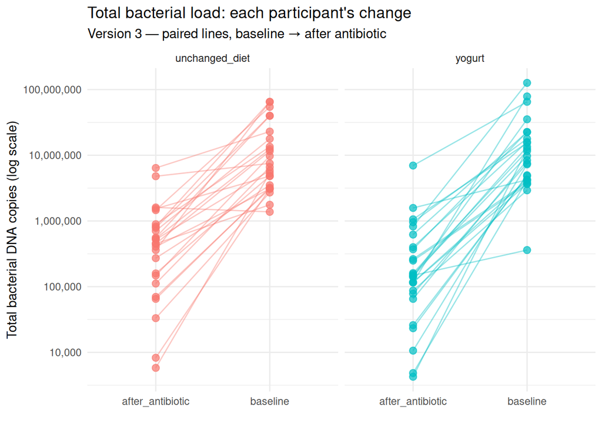

```r
# Reshape so we have one row per participant with baseline and after values
paired_bacteria <- qjoined |>
  select(pid, arm, time_point, qpcr_bacteria) |>
  pivot_wider(names_from = time_point, values_from = qpcr_bacteria)

p3 <- paired_bacteria |>
  ggplot(aes(x = "baseline", y = baseline)) +
  geom_point(aes(color = arm), size = 2.5, alpha = 0.7) +
  geom_segment(aes(x = "baseline", xend = "after_antibiotic",
                   y = baseline, yend = after_antibiotic,
                   color = arm, group = pid),
               alpha = 0.4) +
  geom_point(aes(x = "after_antibiotic", y = after_antibiotic, color = arm),
             size = 2.5, alpha = 0.7) +
  scale_y_log10(labels = scales::comma) +
  facet_wrap(~ arm) +
  labs(title = "Total bacterial load: each participant's change",
       subtitle = "Version 3 — paired lines, baseline → after antibiotic",
       y = "Total bacterial DNA copies (log scale)", x = "") +
  theme_minimal() +
  theme(legend.position = "none")
p3
```

## 6. What we learned

### Making one plot three times taught us

1. **Raw scale**: useless when data spans 4+ orders of magnitude
2. **Log scale + jitter**: reveals structure, shows individual points
3. **Paired lines**: answers the real question — what happens *within* each person from baseline to after treatment